# Point pattern analysis example

Allison Horst

2/26/2020

- Using: Sage grouse telemetry, Mono County:
- Data summary: CA DFG sage grouse telemetry (Mono County)
- Files: ds68 layer
- Contact: William Perry, US Geological Survey (USGS)
- Link: https://map.dfg.ca.gov/metadata/ds0068.html

Info from site: “The purpose of this dataset is to answer questions about sage grouse movement and habitat use in Mono County.”

### Get spatial points and county boundary:

Get the sage grouse data (note: we’ll treat each *observation* as a separate “event” - we’re not taking into account bird ID here):

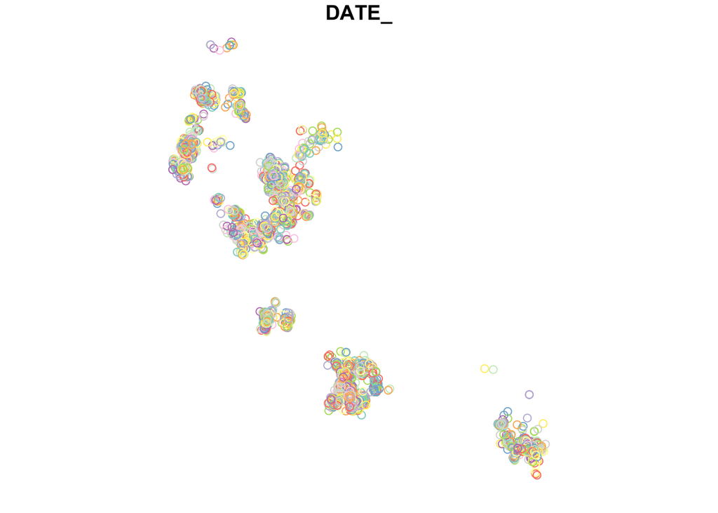

```r
grouse <- read_sf(here("data","sg_data","ds68.shp")) %>%
  dplyr::select(DATE_) %>%
  st_transform(crs = 4326)

# Note: this transform to 6345 *works*, but shouldn't be necessary and messes up the G & L functions...

plot(grouse)
```

Definitely looks clustered. Get the Mono County shapefile:

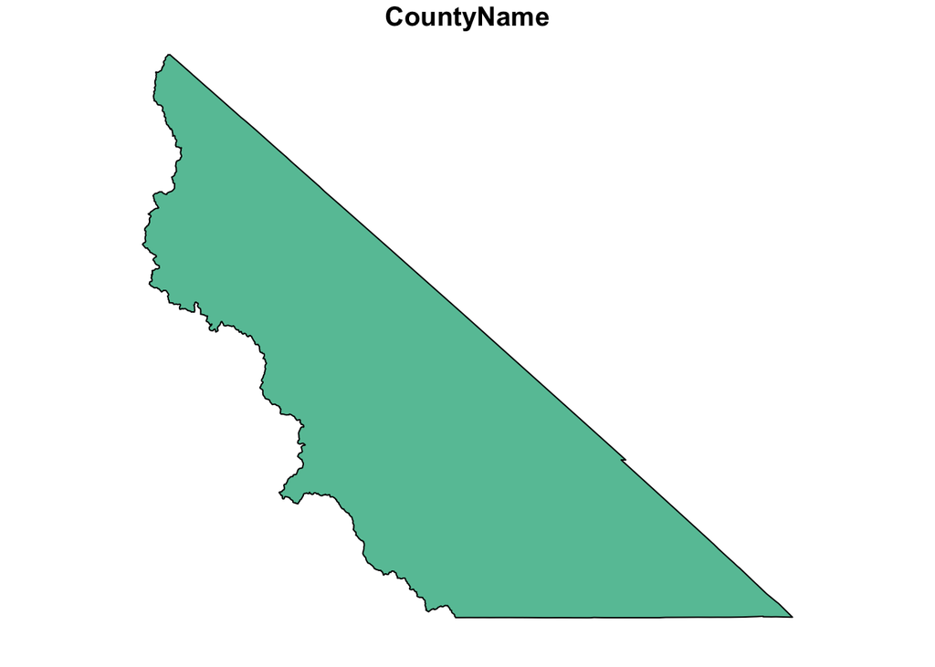

```r
county <- read_sf(dsn = here("data","sg_data","County_Boundaries.shp")) %>% dplyr::select(CountyName) %>%
  st_transform(crs = 4326)

plot(county)
```

Plot them together:

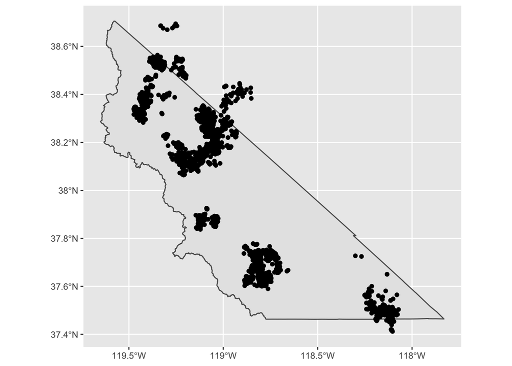

```r
ggplot() +
  geom_sf(data = county) +
  geom_sf(data = grouse)
```

Only keep points that are within the Mono County borders:

```r
mono_grouse <- st_intersection(grouse, county)
```

```
## although coordinates are longitude/latitude, st_intersection assumes that they are planar
```

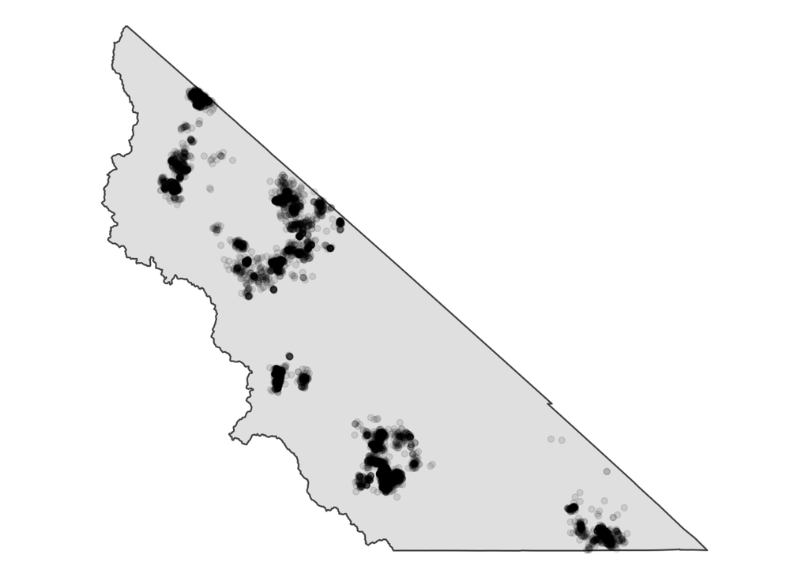

```r
ggplot() +
  geom_sf(data = county) +
  geom_sf(data = mono_grouse, alpha = 0.1) +
  theme_void()
```

```r
# cool.
```

### Now make this a spatial point pattern:

```r
grouse_sp <- as(mono_grouse,"Spatial")
grouse_ppp <- as(grouse_sp, "ppp")

mono_sp <- as(county, "Spatial")
mono_win <- as(mono_sp, "owin")

# Combine as a point pattern (points + window):
grouse_full <- ppp(grouse_ppp$x, grouse_ppp$y, window = mono_win)
```

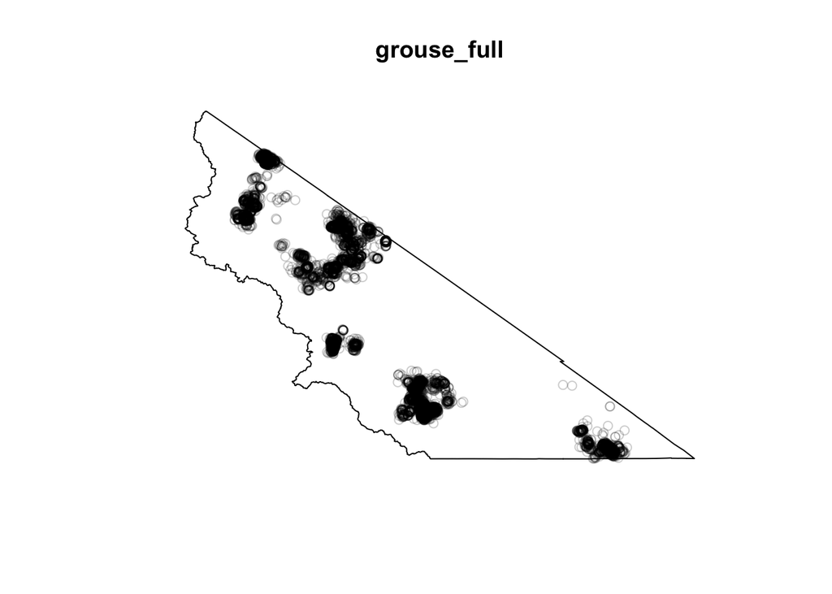

```r
plot(grouse_full)
```

### Quadrat test:

```r
grouse_qt <- quadrat.test(grouse_full, nx = 5, ny = 10)
```

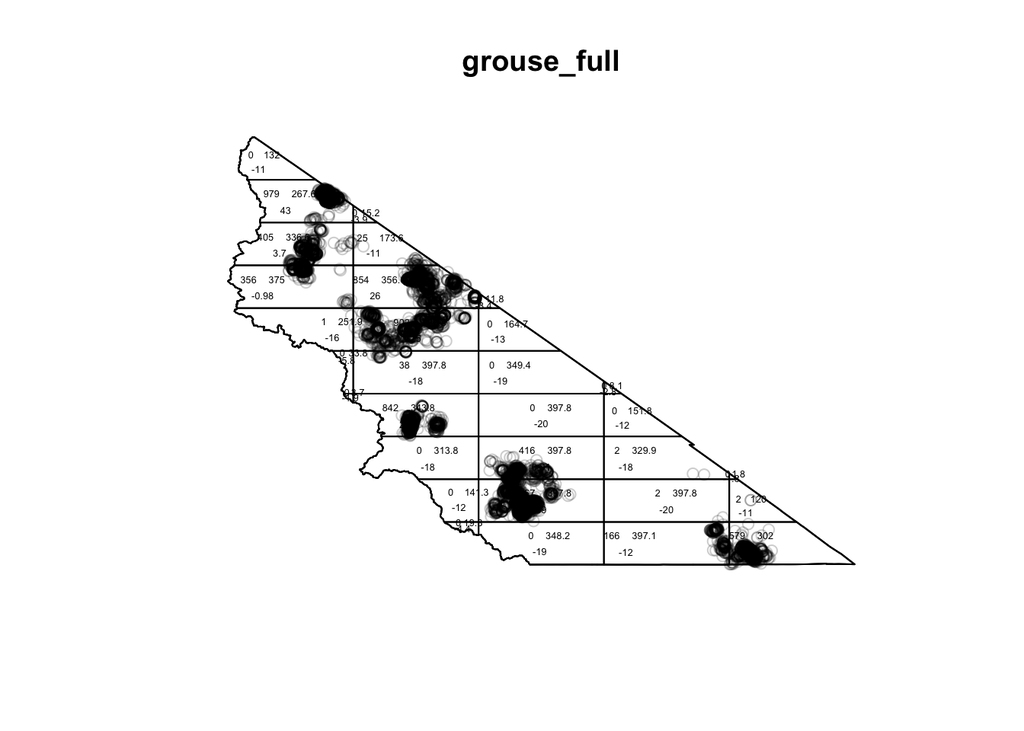

```r
# Look at it:
plot(grouse_full)
plot(grouse_qt, add = TRUE, cex = 0.4)
```

What’s shown on that map? See `?quadrat.test`:

"In all cases, the window of observation is divided into tiles, and the number of data points in each tile is counted, as described in quadratcount. The quadrats are rectangular by default, or may be regions of arbitrary shape specified by the argument tess. The expected number of points in each quadrat is also calculated, as determined by CSR (in the first case) or by the fitted model (in the second case). Then the Pearson X^2 statistic

X^2 = sum((observed - expected)^2/expected)

is computed."

### Density

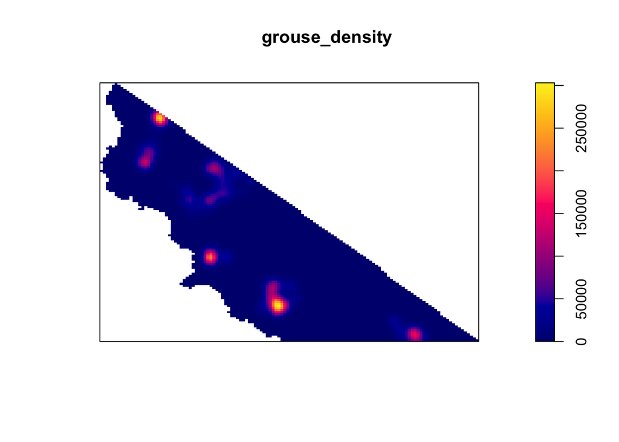

```r
grouse_density <- density(grouse_full, sigma = 0.02)
plot(grouse_density)
```

```r
# r <- seq(0,0.000001, by = 0.0000005)

# gfunction <- envelope(grouse_full, fun = Gest, r = r, nsim = 100, nrank = 2) # Sig level of Monte Carlo = 0.04

# plot(gfunction$obs ~ gfunction$r, type = "l", col = "black", lty = 11)
# lines(gfunction$hi ~ gfunction$r, type = "l", col = "blue", lty = 8)
# lines(gfunction$theo ~ gfunction$r, type = "l", col = "red", lty = 6)
# lines(gfunction$lo ~ gfunction$r, type = "l", col = "green", lty = 4)

# Confirms, in combination with WHAT WE SEE (most importantly), + quadrat.test & density = clustered data!
```